# Prueba Machine Learning : Ramon Yañez, Patricio Zapata

### PREGUNTA 5

**(i) [0.25pt] Aplique el Clustering Jerárquico con k=3 y linkage “ward.D”. Visualice el resultado final con un gráfico dendrograma.**

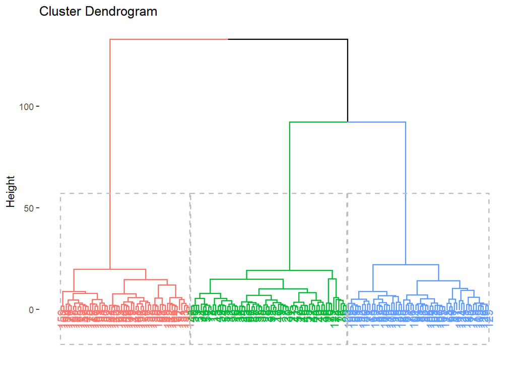

```r
data_5 <-  data[,-1]

# Matriz de distancias euclídeas
d <- dist(data_5, method="euclidean")

# Dendrograma estándar
fviz_dend(hcut(data_5, k=3, hc_method="ward.D"), rect=TRUE)
```

```r
model_hcut <- hcut(data_5, k = 3, hc_method = "ward.D")
```

**(ii) [0.25pt] Haga un PCA con 2 componentes principales y guarde los scores de ambos componentes como nuevas variables.**

```r
# PCA
model_pca <- prcomp(data_5)
model_pca$rotation[,1]
```

```
##         Alcohol           Malic             Ash      Alcalinity       Magnesium
##    -0.144329395     0.245187580     0.002051061     0.239320405    -0.141992042
##         Phenols      Flavanoids   Nonflavanoids Proanthocyanins           Color
##    -0.394660845    -0.422934297     0.298533103    -0.313429488     0.088616705
##             Hue        Dilution         Proline
##    -0.296714564    -0.376167411    -0.286752227
```

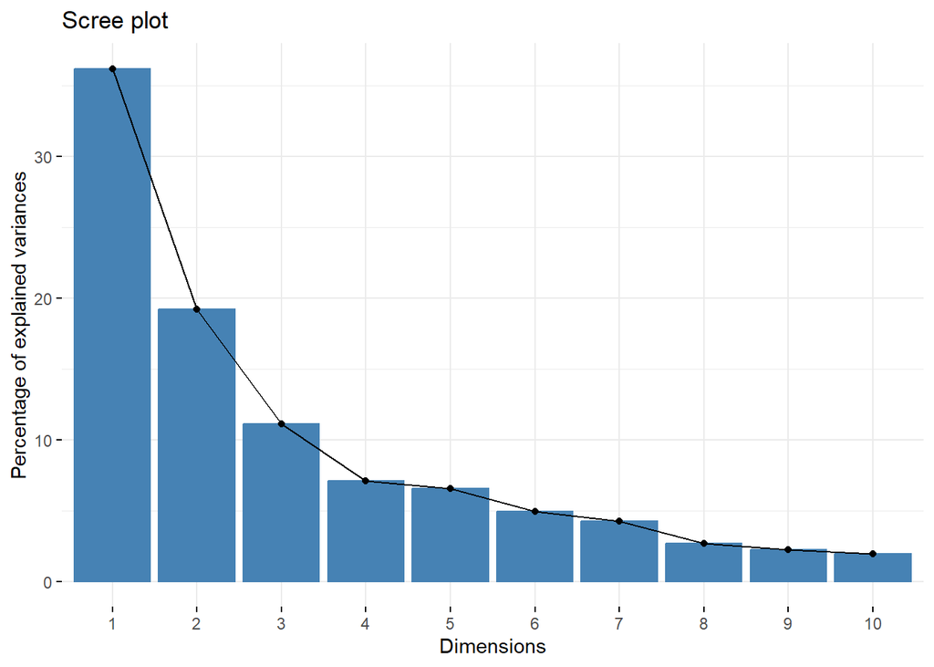

```r
## Seleccion de componentes
# Escojo 2 componentes principales
fviz_eig(model_pca)
```

```r
summary(model_pca)
```

```
## Importance of components:
##                          PC1    PC2    PC3     PC4     PC5     PC6     PC7
## Standard deviation     2.169 1.5802 1.2025 0.95863 0.92370 0.80103 0.74231
## Proportion of Variance 0.362 0.1921 0.1112 0.07069 0.06563 0.04936 0.04239
## Cumulative Proportion  0.362 0.5541 0.6653 0.73599 0.80162 0.85098 0.89337
##                            PC8     PC9   PC10    PC11    PC12    PC13
## Standard deviation     0.59034 0.53748 0.5009 0.47517 0.41082 0.32152
## Proportion of Variance 0.02681 0.02222 0.0193 0.01737 0.01298 0.00795
## Cumulative Proportion  0.92018 0.94240 0.9617 0.97907 0.99205 1.00000
```

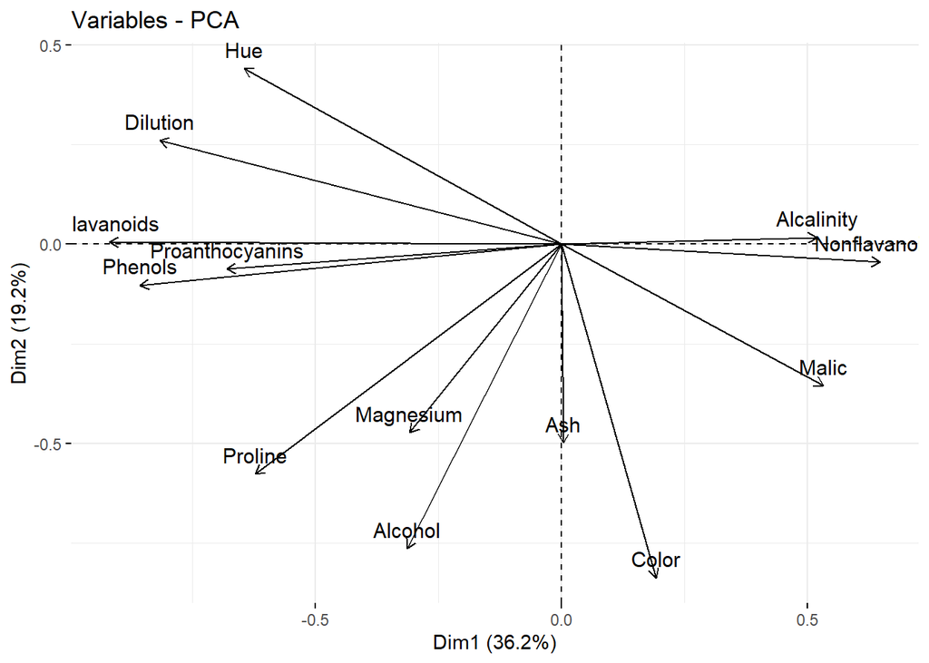

```r
## Grafico de contribucicion  de las variables en PC1 y PC2
fviz_pca_var(model_pca)
```

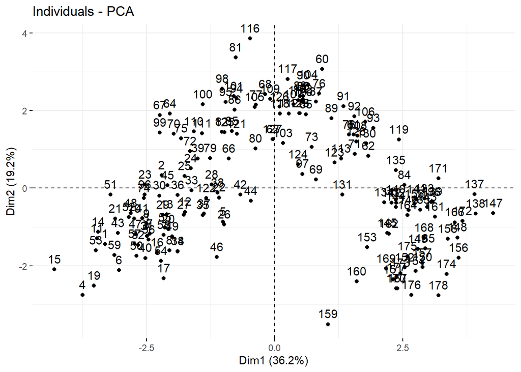

```r
fviz_pca_ind(model_pca)
```

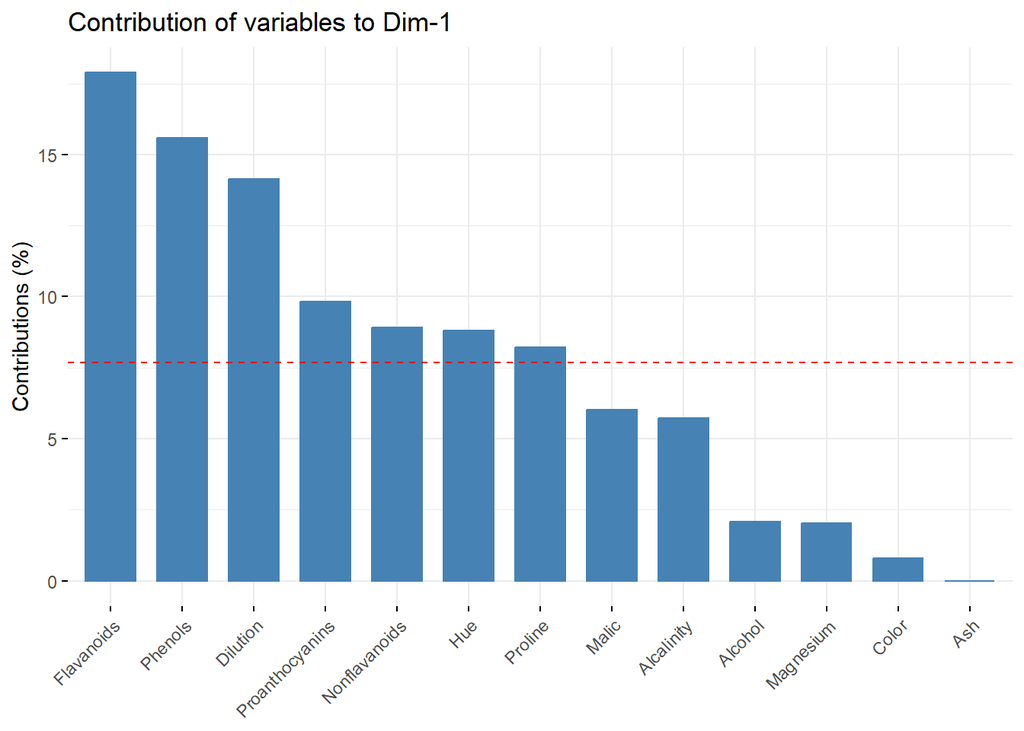

```r
# contribucicion de cada variable en las componentes principales
fviz_contrib(model_pca, choice = "var" , axes = 1)
```

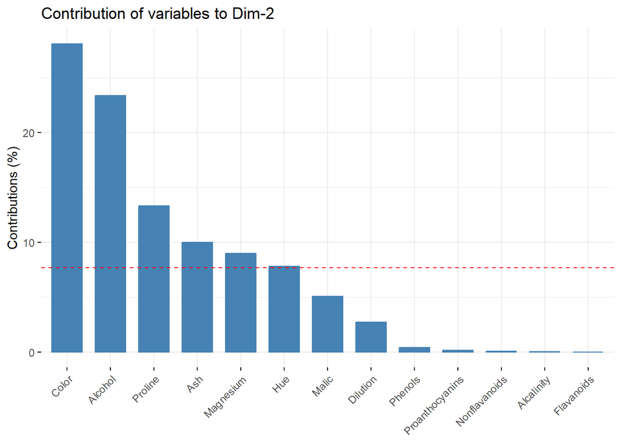

```r
fviz_contrib(model_pca, choice = "var" , axes = 2)
```

```r
# Obtener componentes principales para cada observacion
componentes_principales <- as_tibble(model_pca$x[,1:2])
```

**(iii) [0.25pt] Utilice los scores del ítem anterior para graficar los datos y pinte cada punto según la agrupación calculada con el clustering jerárquico del ítem (i).**

Grafico de visualizacion de clusters

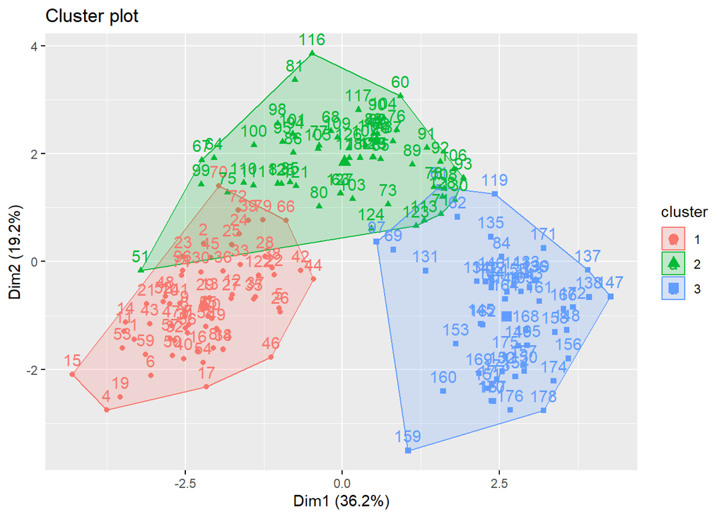

```r
grafico_cluster <- fviz_cluster(model_hcut, data = data_5)
grafico_cluster
```

**(iv) [0.50pt] Haga el mismo gráfico del ítem anterior pero ahora pinte los puntos según el tipo de vino (variable Type). Compare este gráfico con el del ítem (iii) y concluya si la agrupación del clustering jerárquico podría ser un buen clasificador de vinos..**

Grafico de visualizacion de clusters

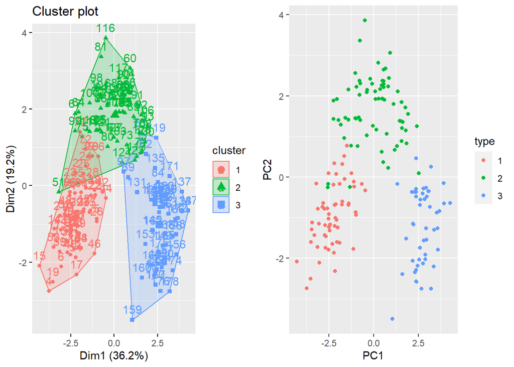

```r
componentes_principales['type'] = data$Type

graficos_componente_type <- ggplot(data = componentes_principales, aes(x=PC1, y=PC2, color=type )) +
  geom_point()



# comparacion del grafico_cluster y graficos_componente_type

grid.arrange(grafico_cluster,graficos_componente_type,  ncol=2)
```

se puede apreciar que ambos graficos son muy similares, pero comparando las clasificaciones de tipo vs las clasificaciones de cluster se puede ver una pequeñas diferencias. se podria decir que el cluster de vinos clasifica bien